# Part I - (Prosper Loan Dataset Explanatory Data Analysis)

## Introduction

> Each of the 113,937 loans in the Propser Loan Data Set has 81 variables, including the Loan Origination Date,Monthly Loan Payment, loan amount, borrower rate (or interest rate), current loan status, borrower income, and many more. The dataset includes data on peer-to-peer loans made possible by the Prosper credit company.

## Preliminary Wrangling

```python
# import all packages and set plots to be embedded inline
import numpy as np
import pandas as pd
import matplotlib.pyplot as plt
import seaborn as sb
from pywaffle import Waffle

%matplotlib inline
import warnings
warnings.filterwarnings('ignore')
```

```python
#loading the dataset into a dataframe
df = pd.read_csv('prosperLoanData.csv')
df
```

|  | ListingKey | ListingNumber | ListingCreationDate | CreditGrade | Term | LoanStatus | ClosedDate | BorrowerAPR | BorrowerRate | LenderYield | ... | LP_ServiceFees | LP_CollectionFees | LP_GrossPrincipalLoss | LP_NetPrincipalLoss | LP_NonPrincipalRecoverypayments | PercentFunded | Recommendations | InvestmentFromFriendsCount | InvestmentFromFriendsAmount | Investors |
| --- | --- | --- | --- | --- | --- | --- | --- | --- | --- | --- | --- | --- | --- | --- | --- | --- | --- | --- | --- | --- | --- |
| 0 | 1021339766868145413AB3B | 193129 | 09:29.3 | C | 36 | Completed | 14/08/2009 00:00 | 0.16516 | 0.1580 | 0.1380 | ... | -133.18 | 0.0 | 0.0 | 0.0 | 0.0 | 1.0 | 0 | 0 | 0.0 | 258 |
| 1 | 10273602499503308B223C1 | 1209647 | 28:07.9 | NaN | 36 | Current | NaN | 0.12016 | 0.0920 | 0.0820 | ... | 0.00 | 0.0 | 0.0 | 0.0 | 0.0 | 1.0 | 0 | 0 | 0.0 | 1 |
| 2 | 0EE9337825851032864889A | 81716 | 00:47.1 | HR | 36 | Completed | 17/12/2009 00:00 | 0.28269 | 0.2750 | 0.2400 | ... | -24.20 | 0.0 | 0.0 | 0.0 | 0.0 | 1.0 | 0 | 0 | 0.0 | 41 |
| 3 | 0EF5356002482715299901A | 658116 | 02:35.0 | NaN | 36 | Current | NaN | 0.12528 | 0.0974 | 0.0874 | ... | -108.01 | 0.0 | 0.0 | 0.0 | 0.0 | 1.0 | 0 | 0 | 0.0 | 158 |
| 4 | 0F023589499656230C5E3E2 | 909464 | 38:39.1 | NaN | 36 | Current | NaN | 0.24614 | 0.2085 | 0.1985 | ... | -60.27 | 0.0 | 0.0 | 0.0 | 0.0 | 1.0 | 0 | 0 | 0.0 | 20 |
| ... | ... | ... | ... | ... | ... | ... | ... | ... | ... | ... | ... | ... | ... | ... | ... | ... | ... | ... | ... | ... | ... |
| 113932 | E6D9357655724827169606C | 753087 | 55:02.7 | NaN | 36 | Current | NaN | 0.22354 | 0.1864 | 0.1764 | ... | -75.58 | 0.0 | 0.0 | 0.0 | 0.0 | 1.0 | 0 | 0 | 0.0 | 1 |
| 113933 | E6DB353036033497292EE43 | 537216 | 42:55.3 | NaN | 36 | FinalPaymentInProgress | NaN | 0.13220 | 0.1110 | 0.1010 | ... | -30.05 | 0.0 | 0.0 | 0.0 | 0.0 | 1.0 | 0 | 0 | 0.0 | 22 |
| 113934 | E6E13596170052029692BB1 | 1069178 | 49:12.7 | NaN | 60 | Current | NaN | 0.23984 | 0.2150 | 0.2050 | ... | -16.91 | 0.0 | 0.0 | 0.0 | 0.0 | 1.0 | 0 | 0 | 0.0 | 119 |
| 113935 | E6EB3531504622671970D9E | 539056 | 18:26.6 | NaN | 60 | Completed | 13/08/2013 00:00 | 0.28408 | 0.2605 | 0.2505 | ... | -235.05 | 0.0 | 0.0 | 0.0 | 0.0 | 1.0 | 0 | 0 | 0.0 | 274 |
| 113936 | E6ED3600409833199F711B7 | 1140093 | 27:37.7 | NaN | 36 | Current | NaN | 0.13189 | 0.1039 | 0.0939 | ... | -1.70 | 0.0 | 0.0 | 0.0 | 0.0 | 1.0 | 0 | 0 | 0.0 | 1 |

113937 rows × 81 columns

```python
#displaying the first five rows in the dataframe
df.head()
```

|  | ListingKey | ListingNumber | ListingCreationDate | CreditGrade | Term | LoanStatus | ClosedDate | BorrowerAPR | BorrowerRate | LenderYield | ... | LP_ServiceFees | LP_CollectionFees | LP_GrossPrincipalLoss | LP_NetPrincipalLoss | LP_NonPrincipalRecoverypayments | PercentFunded | Recommendations | InvestmentFromFriendsCount | InvestmentFromFriendsAmount | Investors |
| --- | --- | --- | --- | --- | --- | --- | --- | --- | --- | --- | --- | --- | --- | --- | --- | --- | --- | --- | --- | --- | --- |
| 0 | 1021339766868145413AB3B | 193129 | 09:29.3 | C | 36 | Completed | 14/08/2009 00:00 | 0.16516 | 0.1580 | 0.1380 | ... | -133.18 | 0.0 | 0.0 | 0.0 | 0.0 | 1.0 | 0 | 0 | 0.0 | 258 |
| 1 | 10273602499503308B223C1 | 1209647 | 28:07.9 | NaN | 36 | Current | NaN | 0.12016 | 0.0920 | 0.0820 | ... | 0.00 | 0.0 | 0.0 | 0.0 | 0.0 | 1.0 | 0 | 0 | 0.0 | 1 |
| 2 | 0EE9337825851032864889A | 81716 | 00:47.1 | HR | 36 | Completed | 17/12/2009 00:00 | 0.28269 | 0.2750 | 0.2400 | ... | -24.20 | 0.0 | 0.0 | 0.0 | 0.0 | 1.0 | 0 | 0 | 0.0 | 41 |
| 3 | 0EF5356002482715299901A | 658116 | 02:35.0 | NaN | 36 | Current | NaN | 0.12528 | 0.0974 | 0.0874 | ... | -108.01 | 0.0 | 0.0 | 0.0 | 0.0 | 1.0 | 0 | 0 | 0.0 | 158 |
| 4 | 0F023589499656230C5E3E2 | 909464 | 38:39.1 | NaN | 36 | Current | NaN | 0.24614 | 0.2085 | 0.1985 | ... | -60.27 | 0.0 | 0.0 | 0.0 | 0.0 | 1.0 | 0 | 0 | 0.0 | 20 |

5 rows × 81 columns

```python
#displaying the last five rows in the dataframe
df.tail()
```

|  | ListingKey | ListingNumber | ListingCreationDate | CreditGrade | Term | LoanStatus | ClosedDate | BorrowerAPR | BorrowerRate | LenderYield | ... | LP_ServiceFees | LP_CollectionFees | LP_GrossPrincipalLoss | LP_NetPrincipalLoss | LP_NonPrincipalRecoverypayments | PercentFunded | Recommendations | InvestmentFromFriendsCount | InvestmentFromFriendsAmount | Investors |
| --- | --- | --- | --- | --- | --- | --- | --- | --- | --- | --- | --- | --- | --- | --- | --- | --- | --- | --- | --- | --- | --- |
| 113932 | E6D9357655724827169606C | 753087 | 55:02.7 | NaN | 36 | Current | NaN | 0.22354 | 0.1864 | 0.1764 | ... | -75.58 | 0.0 | 0.0 | 0.0 | 0.0 | 1.0 | 0 | 0 | 0.0 | 1 |
| 113933 | E6DB353036033497292EE43 | 537216 | 42:55.3 | NaN | 36 | FinalPaymentInProgress | NaN | 0.13220 | 0.1110 | 0.1010 | ... | -30.05 | 0.0 | 0.0 | 0.0 | 0.0 | 1.0 | 0 | 0 | 0.0 | 22 |
| 113934 | E6E13596170052029692BB1 | 1069178 | 49:12.7 | NaN | 60 | Current | NaN | 0.23984 | 0.2150 | 0.2050 | ... | -16.91 | 0.0 | 0.0 | 0.0 | 0.0 | 1.0 | 0 | 0 | 0.0 | 119 |
| 113935 | E6EB3531504622671970D9E | 539056 | 18:26.6 | NaN | 60 | Completed | 13/08/2013 00:00 | 0.28408 | 0.2605 | 0.2505 | ... | -235.05 | 0.0 | 0.0 | 0.0 | 0.0 | 1.0 | 0 | 0 | 0.0 | 274 |
| 113936 | E6ED3600409833199F711B7 | 1140093 | 27:37.7 | NaN | 36 | Current | NaN | 0.13189 | 0.1039 | 0.0939 | ... | -1.70 | 0.0 | 0.0 | 0.0 | 0.0 | 1.0 | 0 | 0 | 0.0 | 1 |

5 rows × 81 columns

```python
#descriptive statistics for numeric variables
df.describe()
```

|  | ListingNumber | Term | BorrowerAPR | BorrowerRate | LenderYield | EstimatedEffectiveYield | EstimatedLoss | EstimatedReturn | ProsperRating (numeric) | ProsperScore | ... | LP_ServiceFees | LP_CollectionFees | LP_GrossPrincipalLoss | LP_NetPrincipalLoss | LP_NonPrincipalRecoverypayments | PercentFunded | Recommendations | InvestmentFromFriendsCount | InvestmentFromFriendsAmount | Investors |
| --- | --- | --- | --- | --- | --- | --- | --- | --- | --- | --- | --- | --- | --- | --- | --- | --- | --- | --- | --- | --- | --- |
| count | 1.139370e+05 | 113937.000000 | 113912.000000 | 113937.000000 | 113937.000000 | 84853.000000 | 84853.000000 | 84853.000000 | 84853.000000 | 84853.000000 | ... | 113937.000000 | 113937.000000 | 113937.000000 | 113937.000000 | 113937.000000 | 113937.000000 | 113937.000000 | 113937.000000 | 113937.000000 | 113937.000000 |
| mean | 6.278857e+05 | 40.830248 | 0.218828 | 0.192764 | 0.182701 | 0.168661 | 0.080306 | 0.096068 | 4.072243 | 5.950067 | ... | -54.725641 | -14.242698 | 700.446342 | 681.420499 | 25.142686 | 0.998584 | 0.048027 | 0.023460 | 16.550751 | 80.475228 |
| std | 3.280762e+05 | 10.436212 | 0.080364 | 0.074818 | 0.074516 | 0.068467 | 0.046764 | 0.030403 | 1.673227 | 2.376501 | ... | 60.675425 | 109.232758 | 2388.513831 | 2357.167068 | 275.657937 | 0.017919 | 0.332353 | 0.232412 | 294.545422 | 103.239020 |
| min | 4.000000e+00 | 12.000000 | 0.006530 | 0.000000 | -0.010000 | -0.182700 | 0.004900 | -0.182700 | 1.000000 | 1.000000 | ... | -664.870000 | -9274.750000 | -94.200000 | -954.550000 | 0.000000 | 0.700000 | 0.000000 | 0.000000 | 0.000000 | 1.000000 |
| 25% | 4.009190e+05 | 36.000000 | 0.156290 | 0.134000 | 0.124200 | 0.115670 | 0.042400 | 0.074080 | 3.000000 | 4.000000 | ... | -73.180000 | 0.000000 | 0.000000 | 0.000000 | 0.000000 | 1.000000 | 0.000000 | 0.000000 | 0.000000 | 2.000000 |
| 50% | 6.005540e+05 | 36.000000 | 0.209760 | 0.184000 | 0.173000 | 0.161500 | 0.072400 | 0.091700 | 4.000000 | 6.000000 | ... | -34.440000 | 0.000000 | 0.000000 | 0.000000 | 0.000000 | 1.000000 | 0.000000 | 0.000000 | 0.000000 | 44.000000 |
| 75% | 8.926340e+05 | 36.000000 | 0.283810 | 0.250000 | 0.240000 | 0.224300 | 0.112000 | 0.116600 | 5.000000 | 8.000000 | ... | -13.920000 | 0.000000 | 0.000000 | 0.000000 | 0.000000 | 1.000000 | 0.000000 | 0.000000 | 0.000000 | 115.000000 |
| max | 1.255725e+06 | 60.000000 | 0.512290 | 0.497500 | 0.492500 | 0.319900 | 0.366000 | 0.283700 | 7.000000 | 11.000000 | ... | 32.060000 | 0.000000 | 25000.000000 | 25000.000000 | 21117.900000 | 1.012500 | 39.000000 | 33.000000 | 25000.000000 | 1189.000000 |

8 rows × 61 columns

```python
#overview and structure of the dataframe
df.info()
```

```
<class 'pandas.core.frame.DataFrame'>
RangeIndex: 113937 entries, 0 to 113936
Data columns (total 81 columns):
 #   Column                               Non-Null Count   Dtype
---  ------                               --------------   -----
 0   ListingKey                           113937 non-null  object
 1   ListingNumber                        113937 non-null  int64
 2   ListingCreationDate                  113937 non-null  object
 3   CreditGrade                          28953 non-null   object
 4   Term                                 113937 non-null  int64
 5   LoanStatus                           113937 non-null  object
 6   ClosedDate                           55089 non-null   object
 7   BorrowerAPR                          113912 non-null  float64
 8   BorrowerRate                         113937 non-null  float64
 9   LenderYield                          113937 non-null  float64
```

[output cut: 73 more lines]

```python
target_variables = ['IsBorrowerHomeowner', 'DebtToIncomeRatio', 'StatedMonthlyIncome', 'LoanOriginalAmount',
                    'LoanOriginationDate', 'MonthlyLoanPayment','Term', 'LoanStatus', 'BorrowerAPR', 'ProsperScore', 'ListingCategory (numeric)', 'EmploymentStatus',
                    'EmploymentStatusDuration']

#extracting the important  variables
dataframe = df[target_variables]
dataframe.head()
```

|  | IsBorrowerHomeowner | DebtToIncomeRatio | StatedMonthlyIncome | LoanOriginalAmount | LoanOriginationDate | MonthlyLoanPayment | Term | LoanStatus | BorrowerAPR | ProsperScore | ListingCategory (numeric) | EmploymentStatus | EmploymentStatusDuration |
| --- | --- | --- | --- | --- | --- | --- | --- | --- | --- | --- | --- | --- | --- |
| 0 | True | 0.17 | 3083.333333 | 9425 | 12/09/2007 00:00 | 330.43 | 36 | Completed | 0.16516 | NaN | 0 | Self-employed | 2.0 |
| 1 | False | 0.18 | 6125.000000 | 10000 | 03/03/2014 00:00 | 318.93 | 36 | Current | 0.12016 | 7.0 | 2 | Employed | 44.0 |
| 2 | False | 0.06 | 2083.333333 | 3001 | 17/01/2007 00:00 | 123.32 | 36 | Completed | 0.28269 | NaN | 0 | Not available | NaN |
| 3 | True | 0.15 | 2875.000000 | 10000 | 01/11/2012 00:00 | 321.45 | 36 | Current | 0.12528 | 9.0 | 16 | Employed | 113.0 |
| 4 | True | 0.26 | 9583.333333 | 15000 | 20/09/2013 00:00 | 563.97 | 36 | Current | 0.24614 | 4.0 | 2 | Employed | 44.0 |

```python
dataframe.info()
```

```
<class 'pandas.core.frame.DataFrame'>
RangeIndex: 113937 entries, 0 to 113936
Data columns (total 13 columns):
 #   Column                     Non-Null Count   Dtype
---  ------                     --------------   -----
 0   IsBorrowerHomeowner        113937 non-null  bool
 1   DebtToIncomeRatio          105383 non-null  float64
 2   StatedMonthlyIncome        113937 non-null  float64
 3   LoanOriginalAmount         113937 non-null  int64
 4   LoanOriginationDate        113937 non-null  object
 5   MonthlyLoanPayment         113937 non-null  float64
 6   Term                       113937 non-null  int64
 7   LoanStatus                 113937 non-null  object
 8   BorrowerAPR                113912 non-null  float64
 9   ProsperScore               84853 non-null   float64
 10  ListingCategory (numeric)  113937 non-null  int64
 11  EmploymentStatus           111682 non-null  object
 12  EmploymentStatusDuration   106312 non-null  float64
dtypes: bool(1), float64(6), int64(3), object(3)
memory usage: 10.5+ MB
```

```python
dataframe.describe()
```

|  | DebtToIncomeRatio | StatedMonthlyIncome | LoanOriginalAmount | MonthlyLoanPayment | Term | BorrowerAPR | ProsperScore | ListingCategory (numeric) | EmploymentStatusDuration |
| --- | --- | --- | --- | --- | --- | --- | --- | --- | --- |
| count | 105383.000000 | 1.139370e+05 | 113937.00000 | 113937.000000 | 113937.000000 | 113912.000000 | 84853.000000 | 113937.000000 | 106312.000000 |
| mean | 0.275947 | 5.608026e+03 | 8337.01385 | 272.475783 | 40.830248 | 0.218828 | 5.950067 | 2.774209 | 96.071582 |
| std | 0.551759 | 7.478497e+03 | 6245.80058 | 192.697812 | 10.436212 | 0.080364 | 2.376501 | 3.996797 | 94.480605 |
| min | 0.000000 | 0.000000e+00 | 1000.00000 | 0.000000 | 12.000000 | 0.006530 | 1.000000 | 0.000000 | 0.000000 |
| 25% | 0.140000 | 3.200333e+03 | 4000.00000 | 131.620000 | 36.000000 | 0.156290 | 4.000000 | 1.000000 | 26.000000 |
| 50% | 0.220000 | 4.666667e+03 | 6500.00000 | 217.740000 | 36.000000 | 0.209760 | 6.000000 | 1.000000 | 67.000000 |
| 75% | 0.320000 | 6.825000e+03 | 12000.00000 | 371.580000 | 36.000000 | 0.283810 | 8.000000 | 3.000000 | 137.000000 |
| max | 10.010000 | 1.750003e+06 | 35000.00000 | 2251.510000 | 60.000000 | 0.512290 | 11.000000 | 20.000000 | 755.000000 |

### Data Cleaning

```python
#rename column names to be easier to type
dataframe.rename(columns={'ListingCategory (numeric)' : 'ListingCategory'}, inplace = True)

#Change the datatype of variables that are incorrectly assigned

#LoanOriginationDate should be datetime datatype
dataframe['LoanOriginationDate'] = pd.to_datetime(dataframe['LoanOriginationDate'])

#replace the missing values in ProsperScore with 0 to indicate 'Not available'
dataframe['ProsperScore'] = dataframe['ProsperScore'].fillna(0)
```

```python
dataframe.info()
```

```
<class 'pandas.core.frame.DataFrame'>
RangeIndex: 113937 entries, 0 to 113936
Data columns (total 13 columns):
 #   Column                    Non-Null Count   Dtype
---  ------                    --------------   -----
 0   IsBorrowerHomeowner       113937 non-null  bool
 1   DebtToIncomeRatio         105383 non-null  float64
 2   StatedMonthlyIncome       113937 non-null  float64
 3   LoanOriginalAmount        113937 non-null  int64
 4   LoanOriginationDate       113937 non-null  datetime64[ns]
 5   MonthlyLoanPayment        113937 non-null  float64
 6   Term                      113937 non-null  int64
 7   LoanStatus                113937 non-null  object
 8   BorrowerAPR               113912 non-null  float64
 9   ProsperScore              113937 non-null  float64
 10  ListingCategory           113937 non-null  int64
 11  EmploymentStatus          111682 non-null  object
 12  EmploymentStatusDuration  106312 non-null  float64
dtypes: bool(1), datetime64[ns](1), float64(6), int64(3), object(2)
memory usage: 10.5+ MB
```

```python
#dealing with the missing values in BorrowerAPR by replacing the missing values with the mean of BorrowerAPR
dataframe['BorrowerAPR'] = dataframe['BorrowerAPR'].fillna(dataframe['BorrowerAPR'].mean())
dataframe.info()
```

```
<class 'pandas.core.frame.DataFrame'>
RangeIndex: 113937 entries, 0 to 113936
Data columns (total 13 columns):
 #   Column                    Non-Null Count   Dtype
---  ------                    --------------   -----
 0   IsBorrowerHomeowner       113937 non-null  bool
 1   DebtToIncomeRatio         105383 non-null  float64
 2   StatedMonthlyIncome       113937 non-null  float64
 3   LoanOriginalAmount        113937 non-null  int64
 4   LoanOriginationDate       113937 non-null  datetime64[ns]
 5   MonthlyLoanPayment        113937 non-null  float64
 6   Term                      113937 non-null  int64
 7   LoanStatus                113937 non-null  object
 8   BorrowerAPR               113937 non-null  float64
 9   ProsperScore              113937 non-null  float64
 10  ListingCategory           113937 non-null  int64
 11  EmploymentStatus          111682 non-null  object
 12  EmploymentStatusDuration  106312 non-null  float64
dtypes: bool(1), datetime64[ns](1), float64(6), int64(3), object(2)
memory usage: 10.5+ MB
```

### What is the structure of your dataset?

> The Original prosper dataset contains over 113k loans with 81 variables. I have selected 13 variables to be used to gain meaningful analysis.

### What is/are the main feature(s) of interest in your dataset?

> The main features of interest in the dataset is the BorrowerAPR features.

### What features in the dataset do you think will help support your investigation into your feature(s) of interest?

> The features that will help support the investigation into the Borrowers APR are LoanOriginalAmount, MonthlyLoanPayment, DebtToOncomeRatio, EmploymentStatus, Term, LoanStatus. etc.

## Univariate Exploration

> In this section, I will investigate distributions of individual variables starting with the main variable of interest then the supporting variables.

### 1. Main variable of interest is the BorrowerAPR

What is the distribution of the BorrowerAPR?

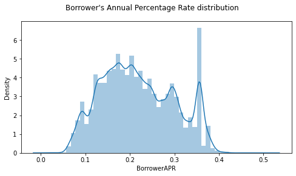

```python
#Distribution of the BorrowerAPR feature
plt.figure(figsize=(8,4))
plt.suptitle("Borrower's Annual Percentage Rate distribution")
sb.distplot(dataframe['BorrowerAPR']);
```

Observation 1. The Borrowers annual percentage rate distribution appears to be multimodal

### 2. LoanOriginalAmount: The origination amount of the loan.

Question: What is the most frequently loaned amount?

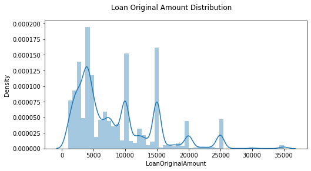

```python
#Distribution of the BorrowerAPR feature
plt.figure(figsize=(8,4))
plt.suptitle("Loan Original Amount Distribution")
sb.distplot(dataframe['LoanOriginalAmount']);
```

```python
dataframe.LoanOriginalAmount.value_counts().nlargest(5)
```

```
4000     14333
15000    12407
10000    11106
5000      6990
2000      6067
Name: LoanOriginalAmount, dtype: int64
```

Observation 2:

```
- The loan amounts are mostly right skewed with different several peaks
- The most frequently loaned amount is $ 4,000
```

### 3. What loan term do majority of the loans fall under?

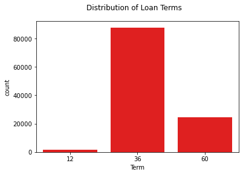

```python
plt.suptitle("Distribution of Loan Terms")
sb.countplot(data = dataframe, x = 'Term', color = 'red');
```

### 4. Loan Status of all the loans on Prosper Credit

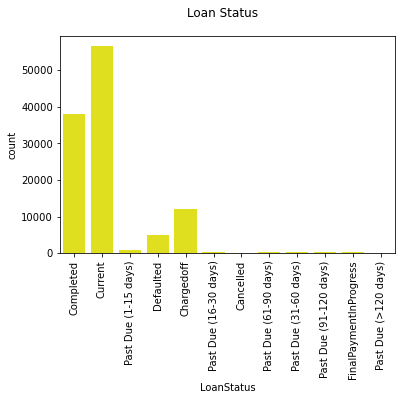

```python
sb.countplot(data = dataframe, x = 'LoanStatus', color = 'yellow');
plt.xticks(rotation = 90)
plt.suptitle("Loan Status");
```

```python
selected = (dataframe['LoanStatus'] == 'Completed') | (dataframe['LoanStatus'] == 'Chargedoff') | (dataframe['LoanStatus'] == 'Defaulted')
dataframe = dataframe[selected]

def change(row):
    if row['LoanStatus'] == 'Chargedoff':
        return 'Defaulted'
    else:
        return row['LoanStatus']

dataframe['LoanStatus'] = dataframe.apply(change, axis=1)
dataframe['LoanStatus'].value_counts()
```

```
Completed    38074
Defaulted    17010
Name: LoanStatus, dtype: int64
```

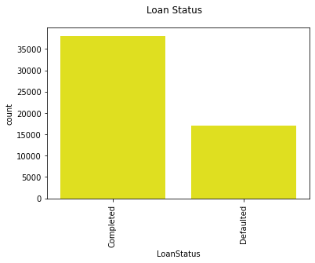

```python
sb.countplot(data = dataframe, x = 'LoanStatus', color = 'yellow');
plt.xticks(rotation = 90)
plt.suptitle("Loan Status");
```

Observation 4: Most of the Loans have a current status with another substantial amount of loans have been completed. The past due loans are split into 6 groups in respect to the number of days they have exceeded.

### 5. Listing Category distribution of the loans

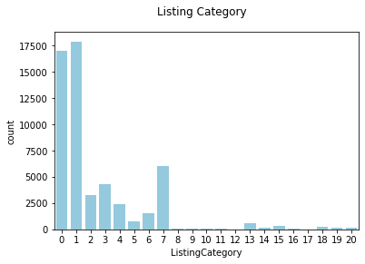

```python
sb.countplot(data = dataframe, x = 'ListingCategory', color = 'skyblue');
plt.xticks(rotation = 360)
plt.suptitle("Listing Category");
```

Observation 5: The most frequently loan category applied for is Debt Consolidation

### 6. Employment Status of the borrowers

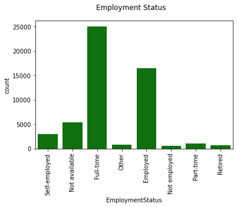

```python
sb.countplot(data = dataframe, x = 'EmploymentStatus', color = "green");
plt.xticks(rotation = 90)
plt.suptitle("Employment Status");
```

Observation 6: Most of the borrowers are employed

### 7. Distribution of Stated Monthly income

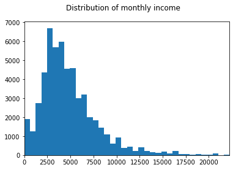

```python
income_std = dataframe['StatedMonthlyIncome'].std()
income_mean = dataframe['StatedMonthlyIncome'].mean()
boundary = income_mean + income_std * 3 #the boundary of the plot by using the mean and 3 parts standard deviation
plt.hist(data=dataframe, x='StatedMonthlyIncome', bins=1000);
plt.xlim(0, boundary)
plt.suptitle("Stated Monthly Income");
plt.suptitle("Distribution of monthly income");
```

## Bivariate Exploration

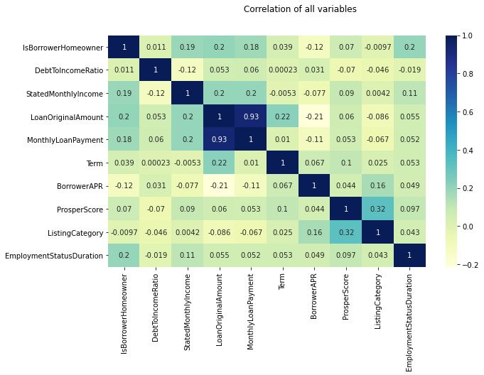

```python
#Correlation plot between the all variables
plt.figure(figsize = [10, 6])
sb.heatmap(dataframe.corr(), cmap="YlGnBu", annot=True)
plt.suptitle("Correlation of all variables");
```

From the correlation heat map above there are some relationships i will like to explore further:

- **Term vs LoanOriginalAmount** with a possitive coefficient of 0.22
- **BorrowerAPR vs LoanOriginalAmount** with a negative coefficient of -0.21
- **EmploymentStatusDuration vs isBorrowerHomeOwner** with a postive coefficient of 0.2
- **isBorrowerHomeOwner vs LoanOriginalAmount** with a positive coefficient of 0.2
- **StatedMonthlyIncome vs LoanOriginalAmount** with a positive coefficient of 0.2
- **StatedMonthlyIncome vs MonthlyLoanPayment** with a positive coefficient of 0.2
- **LoanOriginalAmount vs MonthlyLoanPayment** with a positive coefficient of 0.93

### 1. Term vs LoanOriginalAmount

Question: How does the Loan amount requested for determine the term that the loan would be issued?

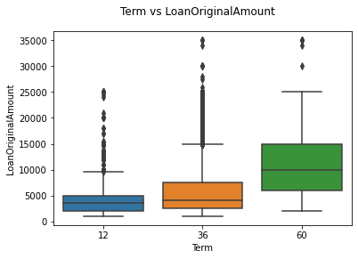

```python
sb.boxplot(x='Term',y='LoanOriginalAmount',data=dataframe)
plt.suptitle("Term vs LoanOriginalAmount");
```

### 2. BorrowerAPR vs LoanOriginalAmount

Question: How does the Loan amount affect the borrowers annual rate percentage?

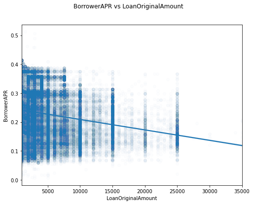

```python
plt.figure(figsize = [8, 6])
sb.regplot(x = 'LoanOriginalAmount' , y = 'BorrowerAPR', data = dataframe, scatter_kws={'alpha':0.01})
plt.suptitle("BorrowerAPR vs LoanOriginalAmount");
```

### 3. EmploymentStatusDuration vs isBorrowerHomeOwner

Question: How does a homeowner and non homeowner compare in terms of the duration of their employment?

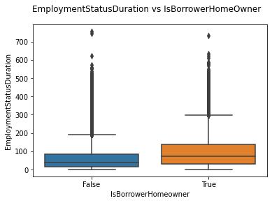

```python
sb.boxplot(x="IsBorrowerHomeowner", y="EmploymentStatusDuration", data=dataframe)
plt.suptitle("EmploymentStatusDuration vs IsBorrowerHomeOwner");
```

Observation 3: It is obvious that borrowers that own homes have more employment history than their counterparts

### 4. isBorrowerHomeOwner vs LoanOriginalAmount

Question: What is the distribution of the amount that was loaned by homeowners and those that were loaned by their counterparts?

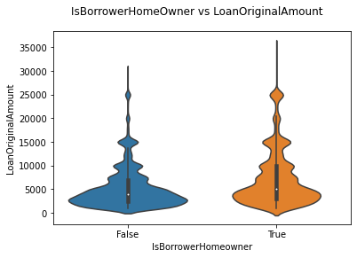

```python
sb.violinplot(x="IsBorrowerHomeowner", y="LoanOriginalAmount", data=dataframe)
plt.suptitle("IsBorrowerHomeOwner vs LoanOriginalAmount");
```

Observation 4: From the graph, it shows that non-homeowners majorly loaned amounts between the ranges of 0 - 5000 with a max of 30000. While most home owners were spread across different amounts betwwen the range of 5000 and above.

### 5. StatedMonthlyIncome vs LoanOriginalAmount

Question: How does the monthly income of a borrower vary with the amount of loan they request for?

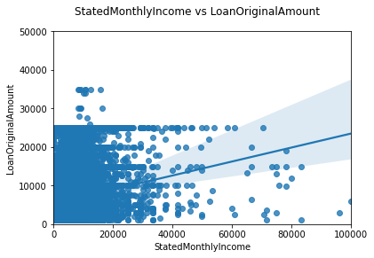

```python
sb.regplot(x = 'StatedMonthlyIncome', y = 'LoanOriginalAmount', data = dataframe)
plt.xlim([0, 100000])
plt.ylim([0, 50000])
plt.suptitle("StatedMonthlyIncome vs LoanOriginalAmount");
```

Observation 5: Borrowers with higher monthly income have higher loan amounts

### 6. StatedMonthlyIncome vs MonthlyLoanPayment

Question: How do borrowers monthly income affect their monthly loan repayment amounts?

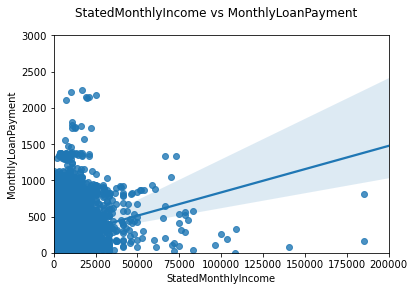

```python
sb.regplot(x = 'StatedMonthlyIncome', y = 'MonthlyLoanPayment', data = dataframe)
plt.xlim([0, 200000])
plt.ylim([0, 3000])
plt.suptitle("StatedMonthlyIncome vs MonthlyLoanPayment");
```

Observation 6: Borrowers with higher monthly income are able to pay higher monthly loan repayments.

### 7. LoanOriginalAmount vs MonthlyLoanPayment

Question: How does the amount of loan issued vary on the monthly repayment amount?

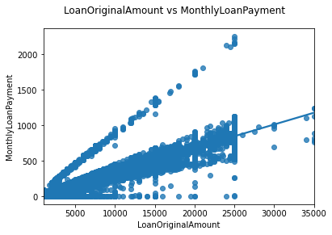

```python
sb.regplot(x = 'LoanOriginalAmount', y = 'MonthlyLoanPayment', data = dataframe)
plt.suptitle("LoanOriginalAmount vs MonthlyLoanPayment");
```

Observation 7: The higher the loan amount the higher the monthly repayment amount

### Talk about some of the relationships you observed in this part of the investigation. How did the feature(s) of interest vary with other features in the dataset?

> - Borrower rate is negatively connected with loan amount. The smaller the borrowers yearly rate %, the larger the loan amount secured. The greater the loan amount, the longer the loan repayment duration. Borrowers having a greater monthly income receive a larger loan amount. Borrowers having a greater monthly income can afford to make larger monthly loan payments. The larger the debt, the greater the monthly payback amount.

### Did you observe any interesting relationships between the other features (not the main feature(s) of interest)?

> Borrowers who own homes clearly have more employment history than their counterparts, and non-homeowners were mostly loaned amounts ranging from 0 to 5000 with a maximum of 30000. While the majority of home owners were spread throughout various sums between 5000 and above.

## Multivariate Exploration

> 1. Effect the term has on the loan amount and the Borrowers Annual rate percentage
> 2. Effect the term has on the loan amount and monthly loan payment

### 1. LoanOriginalAmount vs BorrowerAPR vs Term

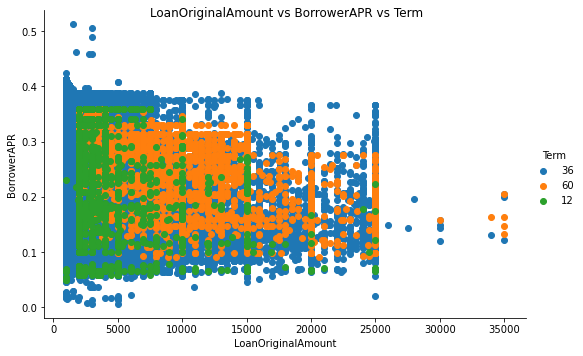

```python
g = sb.FacetGrid(data = dataframe, hue = 'Term',hue_order = [36, 60, 12], size = 5, aspect = 1.5)
g.map(plt.scatter, 'LoanOriginalAmount', 'BorrowerAPR')
g.add_legend()
plt.suptitle("LoanOriginalAmount vs BorrowerAPR vs Term");
```

Observation 1: The 36 months term loans have borrowers annual rate percentage between 0 - 0.4 with a few outliers going to 0.5, Loans for 60 months term are concentrated more on the higher loan amounts and borrowers APR between 0.1 - 0.35, while the 12 months loan term are majorly for lowe loan amounts with a borrowerAPR between 0 - 0.35.

### 2: LoanOriginalAmount vs MonthlyLoanPayment vs Term

Question: Will the monthly loan payments for the different terms be similar?

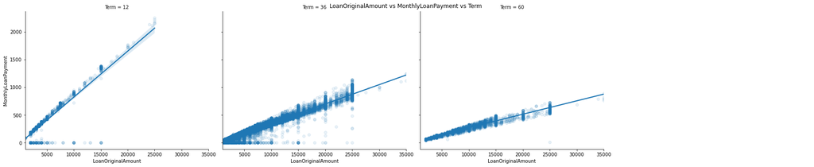

```python
g=sb.FacetGrid(data=dataframe, aspect=1.2, height=5, col='Term', col_wrap=4)
g.map(sb.regplot, 'LoanOriginalAmount', 'MonthlyLoanPayment', x_jitter=0.04, scatter_kws={'alpha':0.1});
g.add_legend()
plt.suptitle("LoanOriginalAmount vs MonthlyLoanPayment vs Term");
```

Observation 2: The above regression graph shows the effect of loan terms on the monthly loan payment to be paid back based on loan amount.

Because the period of a 12-month loan is shorter, the monthly cost is higher than for other terms.

While loans with maturities of 60 months are more evenly distributed.

### Talk about some of the relationships you observed in this part of the investigation. Were there features that strengthened each other in terms of looking at your feature(s) of interest?

> Borrowers' annual percentage rates for 36-month term loans range from 0 to 0.4, with a few outliers reaching 0.5. Borrowers' APR for 60-month term loans range from 0.1 to 0.35, while 12-month term loans are mostly for smaller loan amounts with a borrowerAPR ranging from 0 to 0.35. However, the phrase had no substantial association to improving the effects on the Borrower's annual percentage rate.

### Were there any interesting or surprising interactions between features?

> The influence of loan terms on the monthly loan payment to be paid back based on loan amount was a fascinating discovery. -Because the period of a 12-month loan is shorter, the monthly cost is higher than for other terms. While loans with maturities of 60 months are more evenly distributed.